# Biomedical Statistics Homework 03

- Show All Code
- Hide All Code
- View Source

Author

Zipeng YE (CEBSIT, CAS)

# 1 Question 1

## 1.1 单样本 t 检验（One-Sample t-test）

**1. 假设陈述：**

- **$H_0$：**4 缸汽车的平均 `mpg` $\mu \le 23$。
- **$H_1$：**4 缸汽车的平均 `mpg` $\mu > 23$。

**2. 数据提取与前提假设检查（正态性检验）：**

单样本 t 检验要求数据近似服从正态分布（或样本量 $n > 30$）。使用 Shapiro-Wilk 检验和 Q-Q 图来检查正态性。

```r
# 提取 4 缸汽车的 mpg 数据
data_4cyl <- mtcars$mpg[mtcars$cyl == 4]

# Shapiro-Wilk 正态性检验
shapiro_test <- shapiro.test(data_4cyl)
shapiro_test
```

```
    Shapiro-Wilk normality test

data:  data_4cyl
W = 0.91244, p-value = 0.2606
```

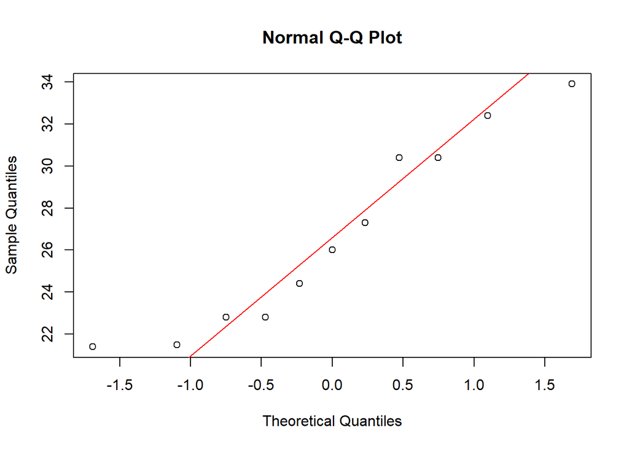

```r
# 绘制 Q-Q 图可视化
qqnorm(data_4cyl) # 绘制 Q-Q 点图
qqline(data_4cyl, col = "red") # 添加符合正态分布的期望直线
```

**前提假设结论：** Shapiro-Wilk 检验的 p-value 为 0.261，大于 0.05，且 Q-Q 图上的点未偏离参考线附近。因此没有足够的证据拒绝正态性假设，可继续进行 t 检验。

**3. 执行右尾 t 检验：**

```r
# 执行右尾 t 检验（alternative = "greater"）
t_test_result <- t.test(data_4cyl, mu = 23, alternative = "greater")
t_test_result
```

```
    One Sample t-test

data:  data_4cyl
t = 2.6943, df = 10, p-value = 0.01127
alternative hypothesis: true mean is greater than 23
95 percent confidence interval:
 24.19912      Inf
sample estimates:
mean of x
 26.66364
```

**结论：** t 检验的 p-value 为 0.0113，小于 0.05，因此拒绝 $H_0$。有显著的统计学证据表明，4 缸汽车的平均 `mpg` 大于 23。

## 1.2 置换检验（Permutation Test）

在课件展示的双样本置换检验中，$H_0$ 假设两组数据来自同一分布。因此我们通过随机重新分配数据标签、计算新的均值差异，重复多次来模拟 $H_0$ 下的均值差异分布。

而对于本次单样本置换检验，$H_0$ 假设样本数据的均值等于某个特定值（这里是 23）。我们通过中心化数据（减去 $H_0$ 均值），然后随机分配正负号、计算新的均值差异，重复多次来模拟 $H_0$ 下的均值差异分布。

```r
# 设置随机种子以保证结果可重复
set.seed(42)

# 计算原始样本的均值与原假设均值的差（原始统计量）
mu_null <- 23
obs_diff <- mean(data_4cyl) - mu_null

# 中心化数据
centered_data <- data_4cyl - mu_null
n <- length(data_4cyl)
B <- 1000 # 置换次数

# 模拟置换过程：随机分配正负号并计算新的均值差异
perm_diffs <- replicate(B, {
  # sample(c(-1, 1), n, replace = TRUE) 随机生成 1 或 -1，长度为 n
  permuted_sample <- centered_data * sample(c(-1, 1), n, replace = TRUE)

  # 计算置换样本的新的均值差异
  mean(permuted_sample)
})

# 计算经验 p-value
# 因为是右尾检验，故统计模拟均值差异中大于等于观测值的比例
p_value_empirical <- sum(perm_diffs >= obs_diff) / B

cat("均值差异观测值:", obs_diff, "\n")
```

```
均值差异观测值: 3.663636
```

```r
cat("经验 p-value:", p_value_empirical, "\n")
```

```
经验 p-value: 0.013
```

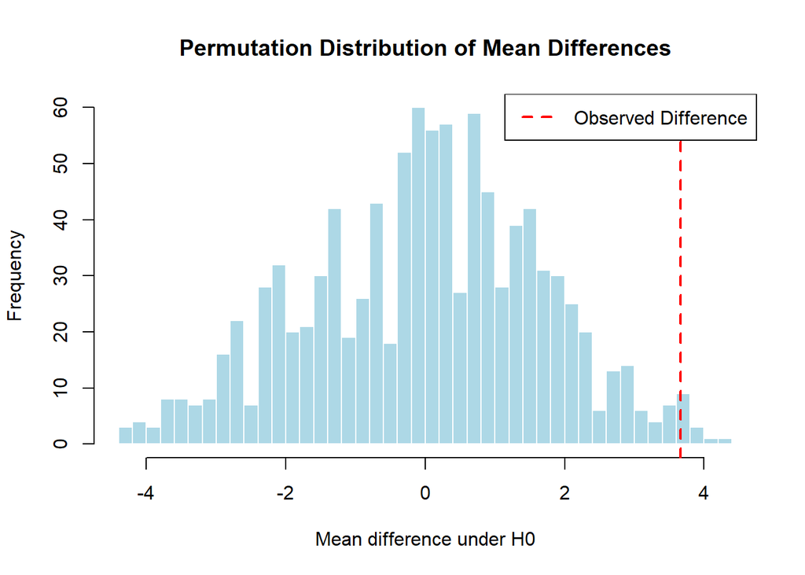

```r
# 可视化置换分布
hist(perm_diffs, breaks = 50, # breaks: 直方图的分箱数量
     col = "lightblue", border = "white",
     main = "Permutation Distribution of Mean Differences",
     xlab = "Mean difference under H0")

# 添加观测值的垂直线
abline(v = obs_diff, col = "red", lwd = 2, lty = 2)
legend("topright", legend = "Observed Difference", col = "red", lwd = 2, lty = 2)
```

**结论：** 置换检验得出的经验 p-value 为 0.013，小于 0.05（且接近 t 检验的 p-value），这与参数 t 检验的结论一致，进一步证实了 4 缸汽车的平均 mpg 显著大于 23。

# 2 Question 2

## 2.1 配对样本 t 检验（Paired t-test）

**1. 假设陈述：**

- **$H_0$：**新学习技巧对成绩没有显著提高，即前后成绩均值之差 $\mu_{after} - \mu_{before} \le 0$。
- **$H_1$：**新学习技巧对成绩有显著提高，即前后成绩均值之差 $\mu_{after} - \mu_{before} > 0$。

**2. 数据输入与正态性检验：**

*（即便题目已明确表示“Conduct a paired t-test”，但严谨起见，我们仍需检查配对差值的正态性，以验证 t 检验的前提假设。）*

配对样本 t 检验要求成对数据差值近似服从正态分布（或样本量 $n > 30$，但这里不满足）。使用 Shapiro-Wilk 检验和 Q-Q 图来检查成绩差值的正态性。

```r
# 输入数据
student_id <- 1:15
score_before <- c(75, 80, 70, 85, 65,
                  90, 78, 72, 88, 76,
                  84, 70, 68, 85, 77)
score_after <- c(85, 82, 78, 88, 70,
                 95, 84, 80, 92, 81,
                 87, 73, 75, 90, 83)

# 计算成绩差值
score_diff <- score_after - score_before

# 正态性检验（Shapiro-Wilk test）
shapiro_test <- shapiro.test(score_diff)
shapiro_test
```

```
    Shapiro-Wilk normality test

data:  score_diff
W = 0.95327, p-value = 0.5773
```

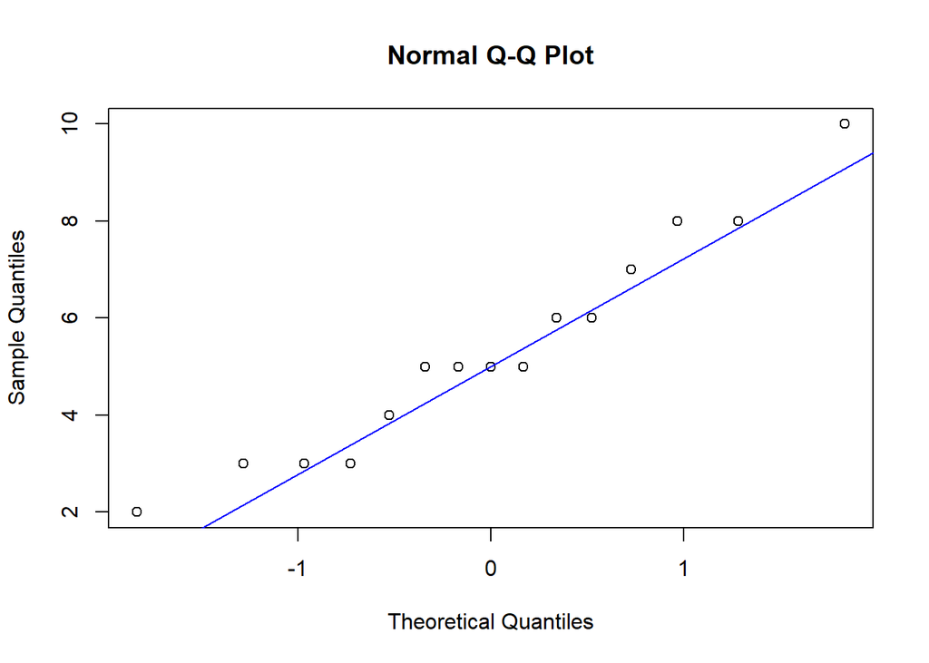

```r
# 绘制 Q-Q 图
qqnorm(score_diff)
qqline(score_diff, col = "blue")
```

**正态性检验结论：** Shapiro-Wilk 检验的 p-value 为 0.577，大于 0.05，且 Q-Q 图上的点未偏离参考线附近。因此没有足够的证据拒绝正态性假设，可以继续进行配对 t 检验。

**3. 执行配对 t 检验：**

显著水平 $\alpha = 0.01$，因此需指定 `conf.level = 0.99`。

```r
# 执行右尾配对 t 检验，设置 paired = TRUE
paired_test_result <- t.test(score_after, score_before,
                             paired = TRUE, conf.level = 0.99, alternative = "greater")
paired_test_result
```

```
    Paired t-test

data:  score_after and score_before
t = 9.2819, df = 14, p-value = 1.166e-07
alternative hypothesis: true mean difference is greater than 0
99 percent confidence interval:
 3.825314      Inf
sample estimates:
mean difference
       5.333333
```

**结论：** 配对 t 检验 p-value 为 1.17e-07，远小于显著水平 $\alpha = 0.01$，因此拒绝 $H_0$。有极显著的统计学证据表明，使用这种新的学习技巧后，学生的测试成绩有极显著提高（平均提高 5.33 分）。

**4. 数据整理与可视化——箱线图：**

绘制箱线图展示使用新技巧前后，学生成绩的分布情况。

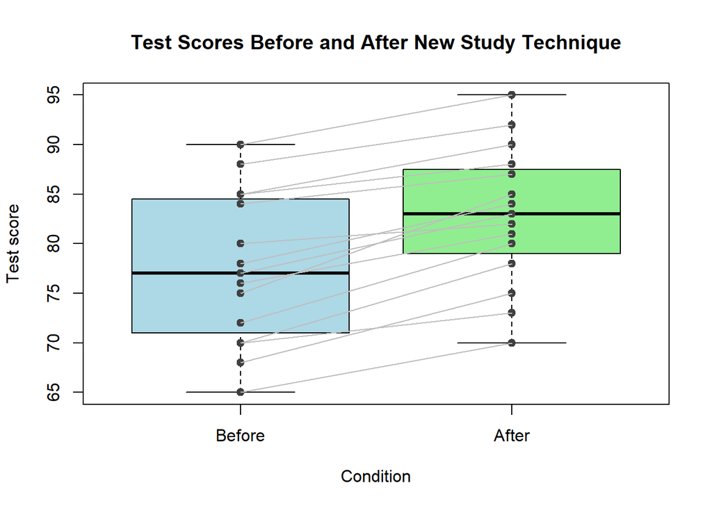

```r
# 将数据转换为数据框以便可视化
study_data <- data.frame(
  Student = factor(rep(student_id, 2)),
  Condition = factor(rep(c("Before", "After"), each = 15), levels = c("Before", "After")),
  Score = c(score_before, score_after)
)

# 绘制箱线图
boxplot(Score ~ Condition, data = study_data,
        col = c("lightblue", "lightgreen"),
        main = "Test Scores Before and After New Study Technique",
        xlab = "Condition",
        ylab = "Test score")

# 添加个体数据点和连线
# stripchart() 用于在箱线图上添加个体数据点，segments() 用于添加连接前后成绩的线段
stripchart(Score ~ Condition,
           data = study_data, vertical = TRUE, # vertical = TRUE 表示点在垂直方向上分布
           add = TRUE, pch = 19, col = "#3f3f3f")
segments(x0 = rep(1, 15), y0 = score_before,
         x1 = rep(2, 15), y1 = score_after,
         col = "grey", lty = 1)
```

*（如图所示，几乎所有学生的成绩在使用了新技巧后都有所提升。）*

# 3 Question 3

## 3.1 两独立样本 t 检验与方差齐性检验 (Unpaired t-test & F-test)

**1. 假设陈述：**

- **方差齐性检验（F-test）：**
  - **$H_0$：**治疗组和安慰剂组的 Cr 变化量方差相等（$\sigma_T^2 = \sigma_P^2$）。
  - **$H_1$：**两组的方差不相等（$\sigma_T^2 \neq \sigma_P^2$）。
- **均值差异检验（t-test）：**
  - **$H_0$：**治疗组的平均 Cr 变化量未高于安慰剂组（$\mu_T \le \mu_P$）。
  - **$H_1$：**治疗组的平均 Cr 变化量显著高于安慰剂组（$\mu_T > \mu_P$）。

**2. 数据输入与正态性检验：**

F 检验要求数据近似服从正态分布；t 检验也要求数据近似服从正态分布（或样本量 $n_T > 30$ 且 $n_P > 30$，但这里不满足）。使用 Shapiro-Wilk 检验和 Q-Q 图来检查两组数据的正态性。

```r
# 1. 输入数据
delta_Cr_placebo <- c(0.00, 0.01, -0.03, -0.01, -0.02,
                      -0.01, 0.03, -0.02, 0.00, 0.04,
                      0.02, -0.02, -0.01, 0.00, -0.03)

delta_Cr_treatment <- c(0.23, 0.08, 0.10, 0.15, 0.09,
                        0.12, 0.19, 0.08, 0.16, 0.10,
                        0.19, 0.12, 0.15, 0.13, 0.14)

# 2. 执行正态性检验（Shapiro-Wilk test & Q-Q plot）
# 安慰剂组
(shapiro_test_placebo <- shapiro.test(delta_Cr_placebo))
```

```
    Shapiro-Wilk normality test

data:  delta_Cr_placebo
W = 0.92998, p-value = 0.2727
```

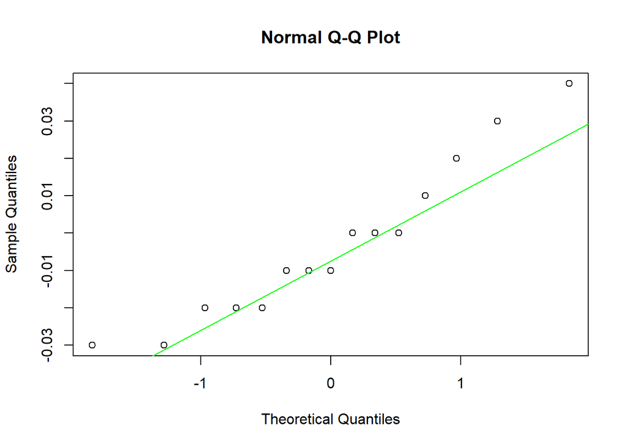

```r
qqnorm(delta_Cr_placebo)
qqline(delta_Cr_placebo, col = "green")
```

```r
# 治疗组
(shapiro_test_treatment <- shapiro.test(delta_Cr_treatment))
```

```
    Shapiro-Wilk normality test

data:  delta_Cr_treatment
W = 0.94333, p-value = 0.426
```

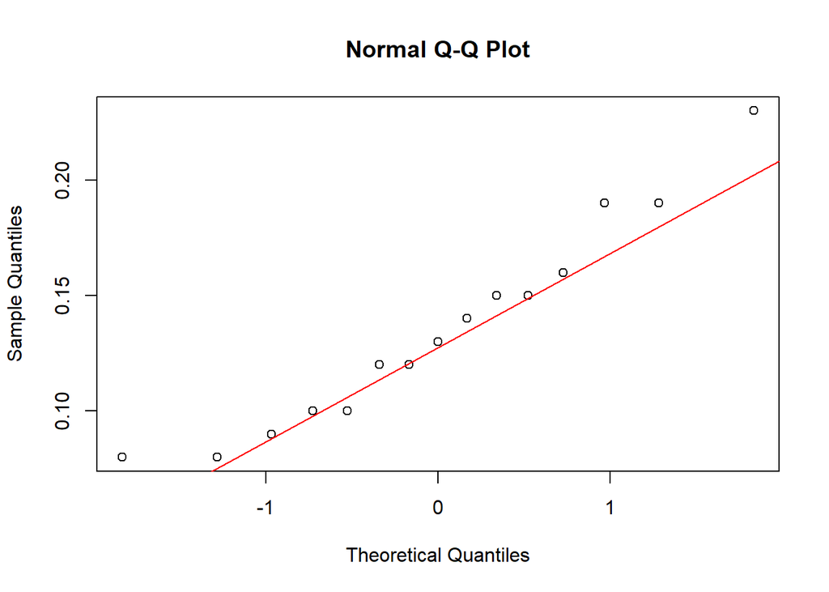

```r
qqnorm(delta_Cr_treatment)
qqline(delta_Cr_treatment, col = "red")
```

**正态性检验分析：**

- 安慰剂组的 Shapiro-Wilk 检验 p-value 为 0.273，大于 0.05，且 Q-Q 图上的点未偏离参考线附近，因此没有足够的证据拒绝正态性假设。
- 治疗组的 Shapiro-Wilk 检验 p-value 为 0.426，大于 0.05，且 Q-Q 图上的点未偏离参考线附近，因此没有足够的证据拒绝正态性假设。
- 两组数据均满足正态性假设，可以继续进行 F 检验和 t 检验。

**3. 执行方差齐性检验：**

```r
# 3. 执行方差齐性检验（F-test）
var_test_result <- var.test(delta_Cr_treatment, delta_Cr_placebo)
var_test_result
```

```
    F test to compare two variances

data:  delta_Cr_treatment and delta_Cr_placebo
F = 4.4304, num df = 14, denom df = 14, p-value = 0.008667
alternative hypothesis: true ratio of variances is not equal to 1
95 percent confidence interval:
  1.487428 13.196438
sample estimates:
ratio of variances
          4.430435
```

**方差检验分析：** F 检验的 p-value 为 0.00867，小于 0.05，因此拒绝 $H_0$，表明两组的方差不相等（方差不齐）。

**4. 执行独立样本 t 检验：**

由于方差不齐，故设定 `var.equal = FALSE` 来执行 Welch t 检验。

```r
# 4. 执行右尾独立样本 t 检验
# 因为方差齐性不成立，故设定 var.equal = FALSE
t_test_result <- t.test(delta_Cr_treatment, delta_Cr_placebo,
                        var.equal = FALSE, alternative = "greater")
t_test_result
```

```
    Welch Two Sample t-test

data:  delta_Cr_treatment and delta_Cr_placebo
t = 11.011, df = 20.014, p-value = 3.037e-10
alternative hypothesis: true difference in means is greater than 0
95 percent confidence interval:
 0.1169467       Inf
sample estimates:
   mean of x    mean of y
 0.135333333 -0.003333333
```

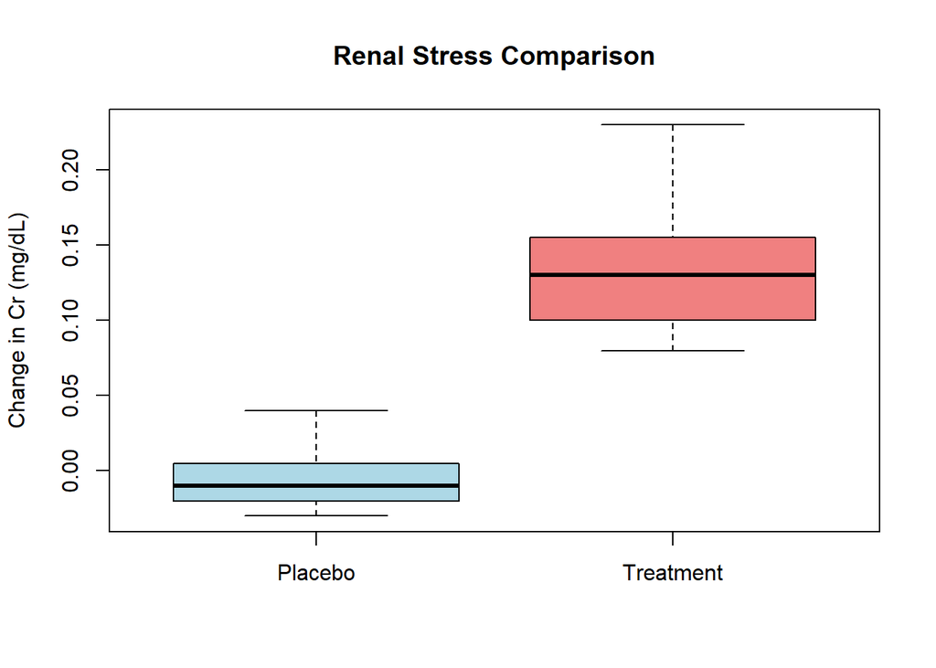

```r
# 可视化两组差异
boxplot(delta_Cr_placebo, delta_Cr_treatment,
        names = c("Placebo", "Treatment"),
        col = c("lightblue", "lightcoral"),
        ylab = "Change in Cr (mg/dL)",
        main = "Renal Stress Comparison")
```

**结论：** 独立样本 t 检验的 p-value 为 3.04e-10，远小于 0.05，因此拒绝 $H_0$。有显著的统计学证据表明，治疗组的平均 Cr 变化量显著高于安慰剂组，提示该药可能与肾脏应激增加相关。

# 4 Question 4

## 4.1 两独立样本 t 检验的手动计算 (Unpaired t-test)

**1. 假设陈述：**

- **$H_0$：**两种抗生素的抑菌圈直径没有显著差异（$\mu_A - \mu_B = 0$）。
- **$H_1$：**两种抗生素的抑菌圈直径存在显著差异（$\mu_A - \mu_B \neq 0$）。

**2. 数据输入与基础统计量计算：**

```r
# 输入数据
group_A <- c(18.5, 19.2, 17.8, 20.1, 19.5, 18.9)
group_B <- c(15.2, 16.8, 14.9, 16.3, 15.8, 16.1)

# 计算样本量
n_A <- length(group_A)
n_B <- length(group_B)

# 计算样本均值
mean_A <- mean(group_A)
mean_B <- mean(group_B)

# 计算样本方差
var_A <- var(group_A)
var_B <- var(group_B)

cat("样本量:", "n_A =", n_A, ", n_B =", n_B, "\n")
```

```
样本量: n_A = 6 , n_B = 6
```

```r
cat("均值:", "mean_A =", round(mean_A, 3), ", mean_B =", round(mean_B, 3), "\n")
```

```
均值: mean_A = 19 , mean_B = 15.85
```

```r
cat("方差:", "var_A =", round(var_A, 3), ", var_B =", round(var_B, 3), "\n")
```

```
方差: var_A = 0.64 , var_B = 0.499
```

**3. 正态性检验与方差齐性检验：**

*（由于题目已告知抑菌圈直径服从正态分布，且两组方差相等，因此这里不再进行正态性检验和方差齐性检验。但在实际分析中，这些步骤是必要的。）*

**4. 计算合并方差 $s_p^2$：**

已知两组方差相等，故需要计算合并方差 $s_p^2$：
$$s_p^2 = \frac{(n_A - 1)s_A^2 + (n_B - 1)s_B^2}{(n_A - 1) + (n_B - 1)}$$

```r
# 自由度
df <- n_A + n_B - 2

# 合并方差
pooled_var <- ((n_A - 1) * var_A + (n_B - 1) * var_B) / df
cat("自由度: df =", df, "\n")
```

```
自由度: df = 10
```

```r
cat("合并方差: s_p^2 =", round(pooled_var, 4), "\n")
```

```
合并方差: s_p^2 = 0.5695
```

**5. 计算标准误 $SE$ 与 t 值：**

标准误 $SE$：
$$SE = \sqrt{s_p^2 \left(\frac{1}{n_A} + \frac{1}{n_B}\right)}$$

t 值：
$$t = \frac{\bar{X}_A - \bar{X}_B}{SE}$$

```r
# 标准误
se <- sqrt(pooled_var * (1/n_A + 1/n_B))

# t 值
t_stat <- (mean_A - mean_B) / se

cat("标准误: SE =", round(se, 4), "\n")
```

```
标准误: SE = 0.4357
```

```r
cat("t 值: t =", round(t_stat, 4), "\n")
```

```
t 值: t = 7.2298
```

**6. 计算 p-value 及结论：**

开展双尾 t 检验。

```r
# 计算双尾 p-value（使用 pt 函数计算 t 分布的累积分布函数）
p_value <- 2 * pt(-abs(t_stat), df) # 乘以 2 是因为双尾检验

cat("p-value =", format.pval(p_value, digits=4), "\n")
```

```
p-value = 2.825e-05
```

**结论：** 经过计算，t 值约为 7.23，对应的 p-value (2.825e-05) 远小于 $\alpha = 0.05$。因此，有足够证据拒绝 $H_0$。抗生素 A 和 B 的抑菌效果（抑菌圈直径）存在显著差异。

# 5 Question 5

## 5.1 实验设计与统计检验方法（Experimental Design and Statistical Test）

**实验设计：**这是一个配对样本设计，测量的是同一组 10 个细胞系在接受新型干扰素处理前后的病毒载量变化，数据点成对而非独立。

**统计检验方法（选择 Wilcoxon 符号秩检验的原因）：**

1. **样本量小：**只有 10 个配对样本（$n=10$）。
2. **非正态性：**数据不满足正态性假设。
3. **配对设计：**每个细胞系在处理前后都有对应的测量值，适合使用配对检验。
4. 因此，依赖正态性假设（数据点服从正态分布或样本量足够大）的配对 t 检验不适用，必须使用基于 Rank 的非参数检验——**Wilcoxon 符号秩检验**。

## 5.2 Wilcoxon 符号秩检验（Wilcoxon Signed-Rank Test）

**1. 假设陈述：**

- **$H_0$：**处理前后的病毒载量无显著差异。
- **$H_1$：**处理前后的病毒载量有显著差异。

**2. 数据输入与检验执行：**

```r
# 1. 输入数据
cell_lines <- 1:10
load_before <- c(6.5, 7.2, 5.8, 8.1, 6.9,
                 7.5, 6.3, 7.8, 7.0, 6.7)
load_after <- c(5.8, 7.0, 5.6, 7.2, 6.1,
                7.6, 5.5, 7.1, 6.8, 6.2)

# 2. 执行检验（必须设置 paired = TRUE，否则变为 Wilcoxon 秩和检验）
wilcox_test_result <- wilcox.test(load_before, load_after, paired = TRUE)
wilcox_test_result
```

```
    Wilcoxon signed rank test with continuity correction

data:  load_before and load_after
V = 54, p-value = 0.007842
alternative hypothesis: true location shift is not equal to 0
```

**检验结果分析：** Wilcoxon 符号秩检验的 p-value 为 0.00784，小于 0.01，因此拒绝 $H_0$，表明处理前后的病毒载量存在极显著差异。

## 5.3 可视化（Boxplot）

题目要求绘制 Boxplot 或 Violin plot。考虑到样本量非常小（$n=10$），不适合绘制小提琴图，因此这里绘制箱线图。

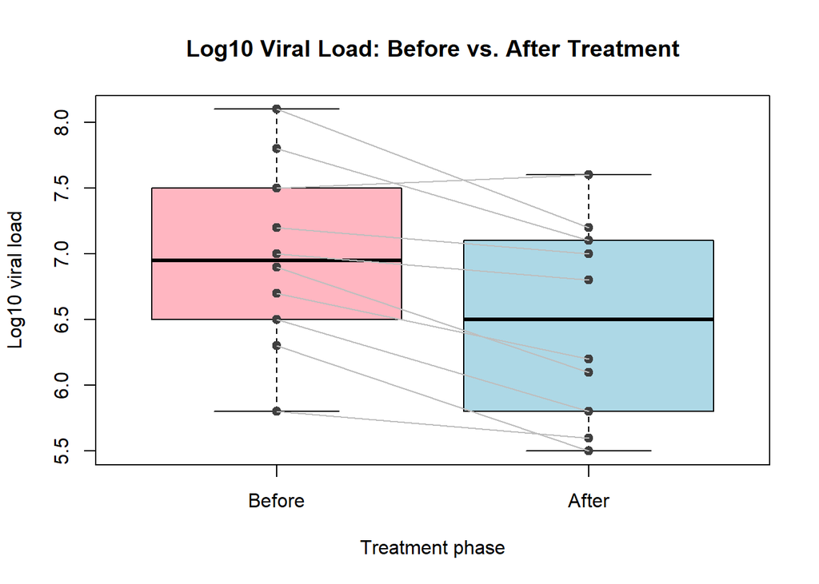

```r
# 将数据转换为长格式方便绘图
viral_data <- data.frame(
  Cell_Line = factor(rep(cell_lines, 2)),
  Timepoint = factor(rep(c("Before", "After"), each = 10), levels = c("Before", "After")),
  Viral_Load = c(load_before, load_after)
)

# 绘制箱线图
boxplot(Viral_Load ~ Timepoint, data = viral_data,
        col = c("lightpink", "lightblue"),
        main = "Log10 Viral Load: Before vs. After Treatment",
        ylab = "Log10 viral load",
        xlab = "Treatment phase")

# 添加配对数据点和连线
stripchart(Viral_Load ~ Timepoint,
           data = viral_data, vertical = TRUE,
           add = TRUE, pch = 19, col = "#3f3f3f")
segments(x0 = rep(1, 10), y0 = load_before,
         x1 = rep(2, 10), y1 = load_after,
         col = "grey", lty = 1)
```

## 5.4 生物学研究意义（Biological Research Significance）

如果在检验中得出的 p-value 小于 0.01（正如在我们的计算中所得到的）：

- **统计学意义：**我们有极强的把握（超过 99%）拒绝 $H_0$，认为处理前后的病毒载量存在显著差异。
- **生物学意义：**结合数据可视化的结果（如图，绝大多数连线呈下降趋势），这意味着该新型干扰素能极显著地抑制细胞内的病毒复制，降低病毒载量。
- **研发意义：**这一发现对于抗病毒药物的开发具有重要意义，表明该干扰素可能是一个有效的抗病毒治疗候选药物。